# Visualizations

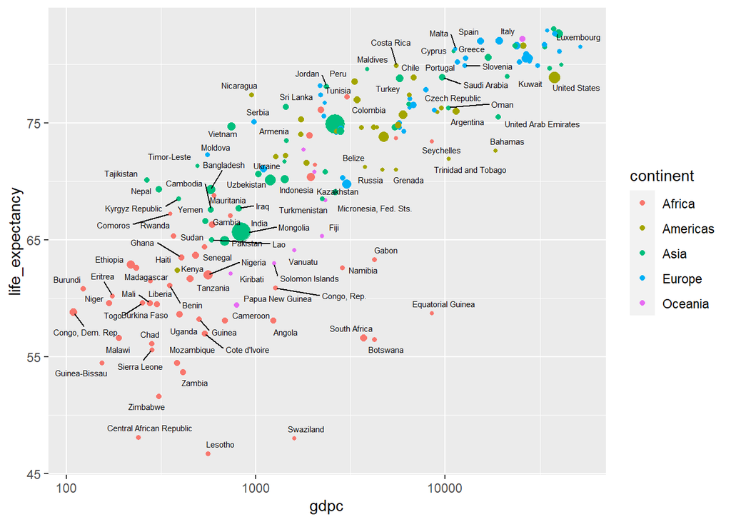

```r
df = gapminder %>% filter(year == 2011) %>%
  mutate(gdpc = gdp / population) %>%
  filter(!is.na(gdpc))


ggplot(data = df, aes(gdpc, life_expectancy)) +
  geom_point(aes(color = continent, size = population)) +
  scale_x_log10() +
  geom_text_repel(aes(label = country), show.legend = FALSE, size = 2) +
  guides(size = "none")
```

Top streaming services in the US: There are only a few data points on the graph. We can manually create the data frame.

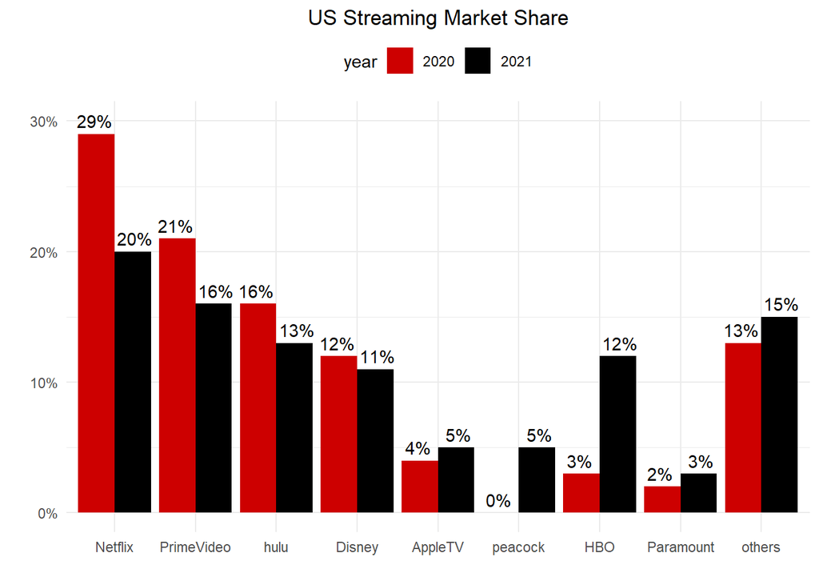

```r
services = c("Netflix", "PrimeVideo", "hulu",
             "Disney", "AppleTV", "peacock", "HBO", "Paramount", "others")
level =  c("Netflix", "PrimeVideo", "hulu",
             "Disney", "AppleTV", "peacock", "HBO", "Paramount", "others")

streaming = tibble::tribble(
  ~service, ~`2020`, ~`2021`,
  "Netflix", 29, 20,
  "Prime", 21, 16,
  "Hulu", 16, 13,
  "Disney", 12, 11,
  "Apple", 4, 5,
  "Peacock", 0, 5,
  "HBO", 3, 12,
  "Paramount", 2, 3,
  "Others", 13, 15
)


y_2020 = c(29,21,16,12,4,0,3,2,13)
y_2021 = c(20,16,13,11,5,5,12,3,15)

df = data.frame(services, y_2020, y_2021)

df = df %>% gather(`y_2020`:`y_2021`, key = "year", value = "pct") %>%
  mutate(year = (str_sub(year, 3, 7))) %>%
  mutate(services = factor(services, ordered = TRUE,
                           levels = level))

ggplot(data = df, aes(services, pct, label = paste0(pct, "%"), fill = year)) +
  geom_col(position = "dodge") +
  geom_text(aes(services, pct + 1, group = year), position = position_dodge(width = 1)) +
  scale_fill_manual(values = c("2020" = "red3", "2021" = "black")) +
  scale_y_continuous(labels = scales::label_number(suffix = "%")) +
  labs(x = "", y= "", title = "US Streaming Market Share") +
  theme_minimal() +
  theme(plot.title = element_text(hjust = 0.5),
        legend.position = "top")
```

improvement

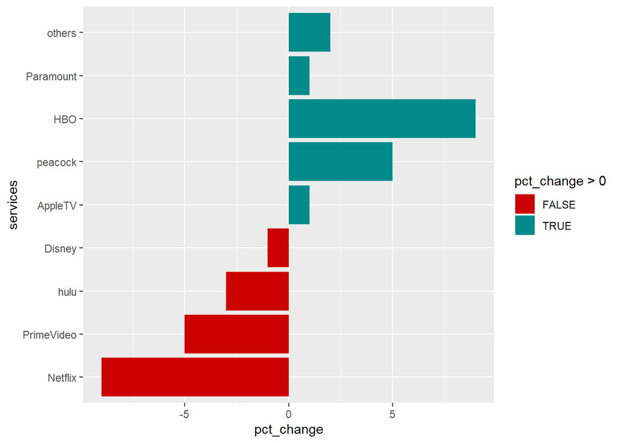

```r
growth = df %>%
  group_by(services) %>%
  mutate(pct_change = pct - lag(pct)) %>%
  na.omit()


ggplot(data= growth) +
  geom_col(aes(services, pct_change, fill = pct_change > 0)) +
  coord_flip() +
  scale_fill_manual(values = c(`TRUE` = "darkcyan", `FALSE` = "red3"))
```

How Chinese New Year compares with Thanksgiving: cny_thanksgiving.xls

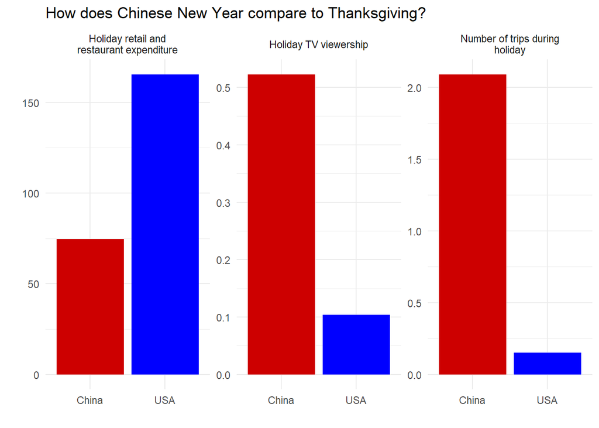

```r
cny = read_excel("../data/cny_thanksgiving.xlsx") %>%
  mutate(Population = case_when(Country == "China" ~ 1339724852,
                                Country == "USA" ~ 307745538),
         Per_capita = Amount/Population,
         Amount = Amount / 1e9) %>%
  filter(Category != "Population Census 2010") %>%
  rename(total = Amount) %>%
  gather(total, Per_capita, key = "mertics", value = "amount")

ggplot(data = cny %>% filter(mertics == "Per_capita"), aes(Country, amount, fill = Country)) +
  geom_col(show.legend = FALSE)+
  facet_wrap(~ Category, scales = "free_y", labeller = label_wrap_gen()) +
  scale_fill_manual(values = c("China" = "red3", "USA" = "blue")) +
  labs(x = "" , y = "", fill = "",
       title = "How does Chinese New Year compare to Thanksgiving?") +
  theme_minimal()
```

Monthly cereal consumption: personal_consumption_expenditures.xlsx.

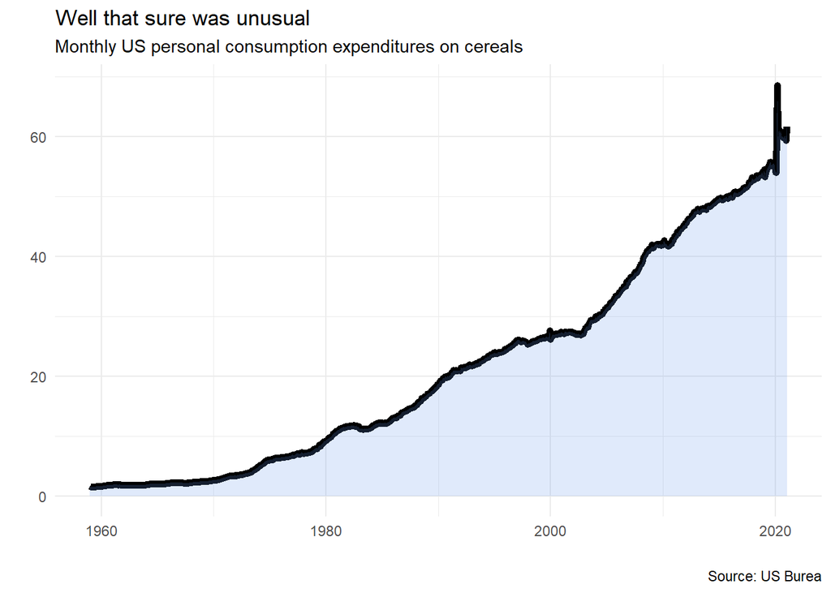

```r
cereal = read_excel("../data/personal_consumption_expenditures.xlsx") %>%
  filter(`Sub-Category` == "Cereals") %>%
  rename(subcat = `Sub-Category`,
         amount = `Millions of Dollars`) %>%
  mutate(amount = amount /1000)

ggplot(data = cereal, aes(x = Month, y = amount)) +
  geom_line(linewidth = 2) +
  geom_area(fill = "cornflowerblue", alpha = 0.2) +
  labs(x= "", y = "", title = "Well that sure was unusual",
       subtitle = "Monthly US personal consumption expenditures on cereals",
       caption = "Source: US Burea") +
  theme_minimal()
```

graph 2

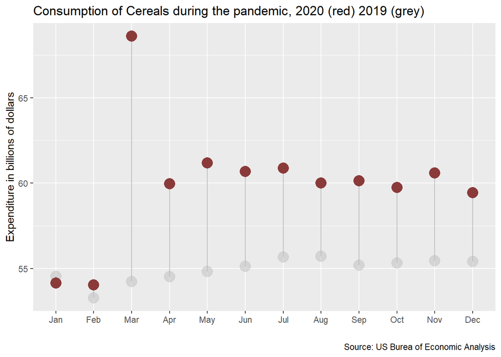

```r
covid = cereal %>% mutate(year = year(Month),
                          month = month(Month, label = TRUE, abbr = TRUE)) %>%
  filter(year == 2020 | year == 2019) %>%
  select(amount:month) %>%
  spread(key = year, value = amount)


ggplot(data = covid, aes(month, amount)) +
    geom_segment(aes(x = month, y = `2020`, xend = month, yend = `2019`), color = "grey") +
  geom_point(data = covid, aes(x = month, y = `2019`), color = "grey", alpha = 0.5, size = 5) +
  geom_point(data = covid, aes(x = month, y =`2020`), color = "indianred4", size = 5) +
  labs(x = "", y= "Expenditure in billions of dollars",
       title = "Consumption of Cereals during the pandemic, 2020 (red) 2019 (grey)",
       caption = "Source: US Burea of Economic Analysis")
```

Who do we spend time with in our life: time-spent-with-relationships-by-age-us.csv.

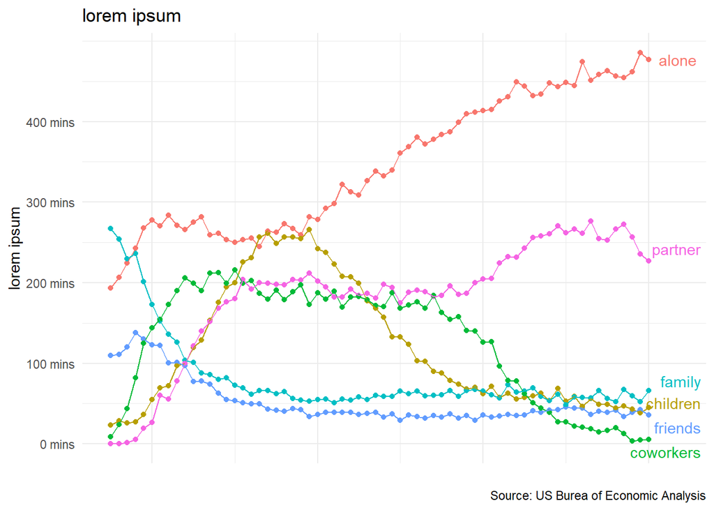

```r
time = read.csv("../data/time-spent-with-relationships-by-age-us.csv")
time = time %>% rename(alone = 4,
                friends = 5,
                children = 6,
                family = `Time.spent.with.with.parents..siblings.and.other.family..by.age.of.respondent..United.States.`,
                partner = `Time.spent.with.partner..by.age.of.respondent..United.States.`,
                coworkers = `Time.spent.with.coworkers..by.age.of.respondent..United.States.`,)

time = time %>% gather(`alone`:`coworkers`, key = "type", value = "minutes") %>%
  filter(Year <= 80)

labels = time %>% filter(Year == 80 )

ggplot(data = time, aes(Year, minutes, color = type), show.legend = FALSE) +
  geom_point(show.legend = FALSE) +
  geom_line(show.legend = FALSE) +
  geom_text_repel(data = labels, aes(label = type), show.legend = FALSE, nudge_x = 3.5) +
  scale_y_continuous(labels = scales::label_number(suffix = " mins"),
                     breaks = seq(0,400,100)) +
  scale_x_continuous(breaks = c(15,20,30,40,50,60,70,80), limits = c(15,90)) +
  labs(x = "Age", y = "",
       title = "Who Americans spend their time with, by age") +
  scale_x_continuous(guide = "none") + # this removes the legend
  theme_minimal() +
  labs(x = "", y= "lorem ipsum",
       title = "lorem ipsum",
       caption = "Source: US Burea of Economic Analysis")
```

NBA plots

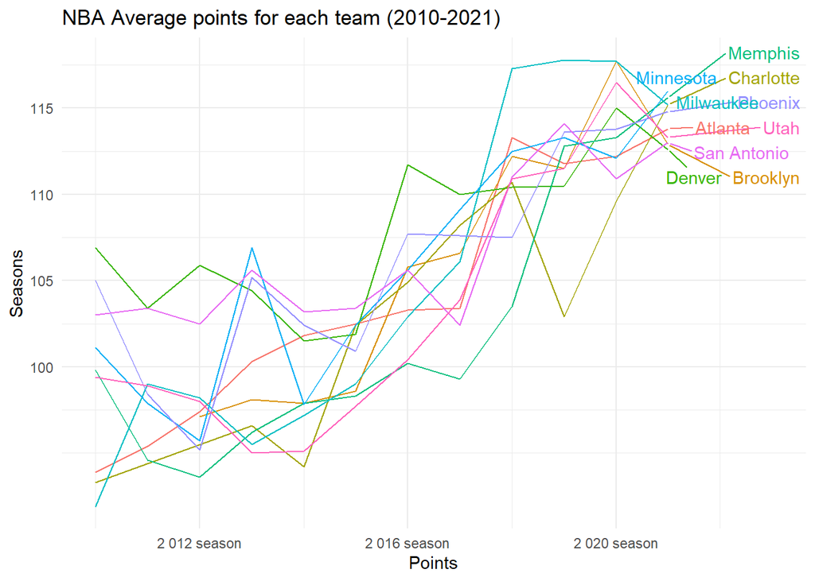

```r
library(ggrepel)
nba = read.csv("../data/NBA_Team_stats.csv") %>%
  separate(Year, into = c("start_year", "end_year"), convert = TRUE) %>%
  filter(start_year >= 2010) %>%
  select(`No`:`Pf`, start_year) %>%
  gather(`Pts`:`Pf`, key = "type", value = "values")

pts = nba %>% filter(type == "Pts")
end_labels = pts %>% filter(start_year == 2021) %>%
  top_n(10, values)

top_10 = end_labels %>% pull(Team)

pts = pts %>% filter(Team %in% top_10)

ggplot(data = pts, aes(start_year, values, color = Team, show.legend = FALSE)) +
  geom_line(aes(groups = Team), show.legend = FALSE) +
  geom_text_repel(data = end_labels, aes(start_year, values, label = Team), show.legend = FALSE,
                  nudge_x = 2) +
  scale_x_continuous(labels = scales::label_number(suffix = " season")) +
  scale_y_continuous(breaks = seq(100,130,5)) +
  labs(x = "Points", y = "Seasons", title = "NBA Average points for each team (2010-2021)" ) +
  theme_minimal()
```

nba players

```r
players = read.csv("../data/NBA_Player_Stats.csv") %>%
  separate(Year, into = c("start", "end")) %>%
  mutate(start = as.numeric(start),
         end = as.numeric(end)) %>%
  filter(start >= 2010)

players %>% distinct(Player)
```

```
##                        Player
## 1                 Jeff Adrien
## 2               Arron Afflalo
## 3                Maurice Ager
## 4               Alexis Ajinça
## 5               Solomon Alabi
## 6                Cole Aldrich
## 7           LaMarcus Aldridge
## 8                 Malik Allen
## 9                  Ray Allen*
## 10                 Tony Allen
## 11            Al-Farouq Aminu
## 12               Lou Amundson
## 13             Chris Andersen
## 14             David Andersen
```

[output cut: 1497 more lines]

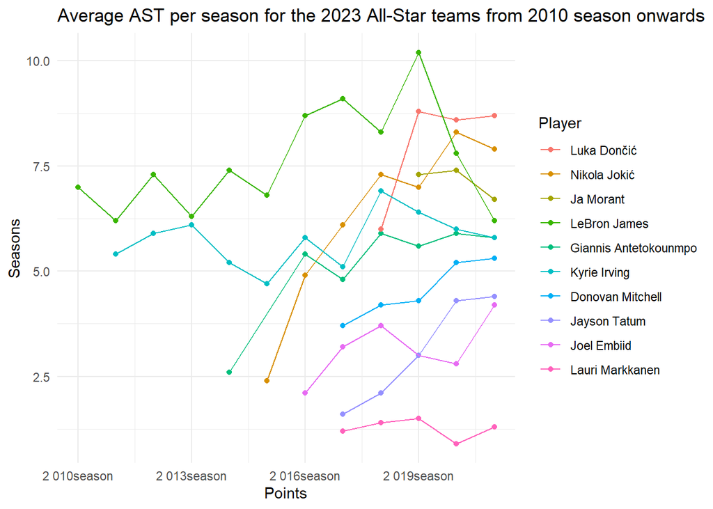

```r
allstars_2023 = c("Giannis Antetokounmpo", "Lauri Markkanen", "Donovan Mitchell", "Ja Morant",
                  "Jayson Tatum", "LeBron James", "Luka Dončić", "Joel Embiid", "Kyrie Irving",
                  "Nikola Jokić")

global_type = "AST"
allstars = players %>% filter(Player %in% allstars_2023) %>%
  gather(`G`:`PTS`, key = "type", value = "values")

end_labelss = allstars %>% filter(end == 2022, type == global_type) %>% arrange(desc(values))

allstars_df = allstars %>% mutate(Player = factor(Player, levels = end_labelss %>% pull(Player)))

ggplot(data = allstars_df %>% filter(type == global_type), aes(start, values, color = Player)) +
  geom_point() +
  geom_line() +
  scale_x_continuous(labels = scales::label_number(suffix = "season")) +
  labs(x = "Points", y = "Seasons",
       title = "Average AST per season for the 2023 All-Star teams from 2010 season onwards") +
  theme_minimal()
```

jimmmy butler

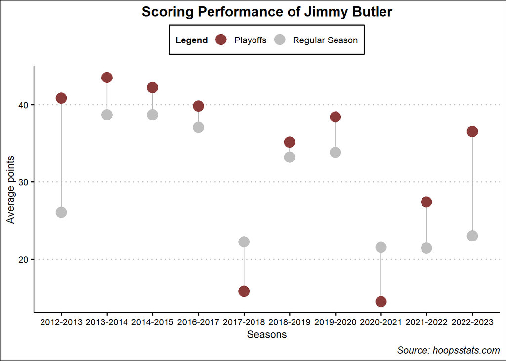

```r
butler = tibble::tribble(
  ~season, ~`reg`, ~`playoffs`,
  "2022-2023", 23.0, 36.5,
  "2021-2022", 21.4, 27.4,
  "2020-2021", 21.5, 14.5,
  "2019-2020", 33.8, 38.4,
  "2018-2019", 33.2, 35.1,
  "2017-2018", 22.2, 15.8,
  "2016-2017", 37.0, 39.8,
  "2014-2015", 38.7, 42.2,
  "2013-2014", 38.7, 43.5,
  "2012-2013", 26.0, 40.8,
)


colors = c("reg" = "grey", "playoffs" = "indianred4")

ggplot(data = butler, aes(season, points)) +
  geom_segment(aes(x = season, y = `reg`, xend = season, yend = `playoffs`), color = "grey")+
  geom_point(data = butler, aes(x = season, y = `reg`, color = "reg"), size = 5) +
  geom_point(data = butler, aes(x = season, y = `playoffs`, color = "playoffs"), size = 5) +
  theme(axis.text.x = element_text(angle = 90, vjust = 0.5, hjust=1)) +
  labs(x = "Seasons", y= "Average points",
       title = "Scoring Performance of Jimmy Butler",
       caption = "Source: hoopsstats.com",
       color = "Legend") +
  scale_color_manual(values = colors,  labels = c("Playoffs", "Regular Season")) +
  theme_clean() +
  theme(plot.title = element_text(hjust = 0.5),
        plot.subtitle = element_text(hjust = 0.5, size = 9, face = "italic"),
        plot.caption = element_text(face = "italic"),
        legend.position = "top",
        legend.title = element_text(size = 9),
        legend.text = element_text(size = 9))
```

```r
butler = butler %>% gather(`reg`:`playoffs`, key = "period", value = "points")
```

BASE R

```r
a1 = seq(13, 21)
a1
```

```
## [1] 13 14 15 16 17 18 19 20 21
```

```r
a2 = seq(13,21, by = 2)
a2
```

```
## [1] 13 15 17 19 21
```

```r
a1 + a2
```

```
## [1] 26 29 32 35 38 31 34 37 40
```

```r
sum(1:100) == 100* (100+1)/2
```

```
## [1] TRUE
```

```r
data(airquality)
summary(airquality)
```

```
##      Ozone           Solar.R           Wind             Temp
##  Min.   :  1.00   Min.   :  7.0   Min.   : 1.700   Min.   :56.00
##  1st Qu.: 18.00   1st Qu.:115.8   1st Qu.: 7.400   1st Qu.:72.00
##  Median : 31.50   Median :205.0   Median : 9.700   Median :79.00
##  Mean   : 42.13   Mean   :185.9   Mean   : 9.958   Mean   :77.88
##  3rd Qu.: 63.25   3rd Qu.:258.8   3rd Qu.:11.500   3rd Qu.:85.00
##  Max.   :168.00   Max.   :334.0   Max.   :20.700   Max.   :97.00
##  NA's   :37       NA's   :7
##      Month            Day
##  Min.   :5.000   Min.   : 1.0
##  1st Qu.:6.000   1st Qu.: 8.0
##  Median :7.000   Median :16.0
##  Mean   :6.993   Mean   :15.8
##  3rd Qu.:8.000   3rd Qu.:23.0
##  Max.   :9.000   Max.   :31.0
##
```

```r
class(airquality)
```

```
## [1] "data.frame"
```

```r
str(airquality)
```

```
## 'data.frame':    153 obs. of  6 variables:
##  $ Ozone  : int  41 36 12 18 NA 28 23 19 8 NA ...
##  $ Solar.R: int  190 118 149 313 NA NA 299 99 19 194 ...
##  $ Wind   : num  7.4 8 12.6 11.5 14.3 14.9 8.6 13.8 20.1 8.6 ...
##  $ Temp   : int  67 72 74 62 56 66 65 59 61 69 ...
##  $ Month  : int  5 5 5 5 5 5 5 5 5 5 ...
##  $ Day    : int  1 2 3 4 5 6 7 8 9 10 ...
```

```r
sum(is.na(airquality ))
```

```
## [1] 44
```

```r
which(is.na(airquality))
```

```
##  [1]   5  10  25  26  27  32  33  34  35  36  37  39  42  43  45  46  52  53  54
## [20]  55  56  57  58  59  60  61  65  72  75  83  84 102 103 107 115 119 150 158
## [39] 159 164 180 249 250 251
```

```r
df = na.omit(airquality)

df_summer = df[df$Month %in% c(5,6),]
df_fall = df[df$Month %in% c(7, 8, 9),]

df$Season = ifelse(df$Month %in% c(5,6), "Summer", "Fall")
df$Season = factor(df$Season)

summary(df$Temp)
```

```
##    Min. 1st Qu.  Median    Mean 3rd Qu.    Max.
##   57.00   71.00   79.00   77.79   84.50   97.00
```

```r
str(df)
```

```
## 'data.frame':    111 obs. of  7 variables:
##  $ Ozone  : int  41 36 12 18 23 19 8 16 11 14 ...
##  $ Solar.R: int  190 118 149 313 299 99 19 256 290 274 ...
##  $ Wind   : num  7.4 8 12.6 11.5 8.6 13.8 20.1 9.7 9.2 10.9 ...
##  $ Temp   : int  67 72 74 62 65 59 61 69 66 68 ...
##  $ Month  : int  5 5 5 5 5 5 5 5 5 5 ...
##  $ Day    : int  1 2 3 4 7 8 9 12 13 14 ...
##  $ Season : Factor w/ 2 levels "Fall","Summer": 2 2 2 2 2 2 2 2 2 2 ...
##  - attr(*, "na.action")= 'omit' Named int [1:42] 5 6 10 11 25 26 27 32 33 34 ...
##   ..- attr(*, "names")= chr [1:42] "5" "6" "10" "11" ...
```

```r
tapply(df$Temp, df$Season, summary)
```

```
## $Fall
##    Min. 1st Qu.  Median    Mean 3rd Qu.    Max.
##   63.00   76.25   81.00   81.23   86.00   97.00
##
## $Summer
##    Min. 1st Qu.  Median    Mean 3rd Qu.    Max.
##   57.00   62.00   68.00   69.67   76.00   90.00
```

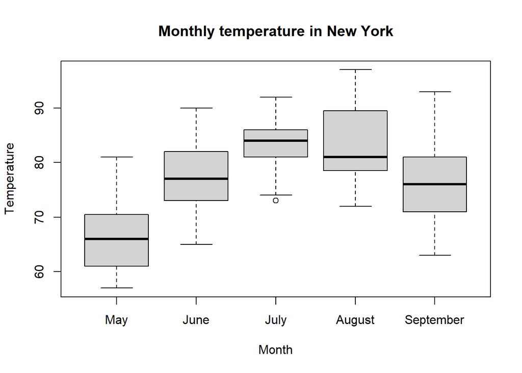

```r
df$Month[df$Month == 5] = "May"
df$Month[df$Month == 6] = "June"
df$Month[df$Month == 7] = "July"
df$Month[df$Month == 8] = "August"
df$Month[df$Month == 9] = "September"
df$Month = factor(df$Month, levels = c("May", "June", "July", "August","September"))


boxplot(df$Temp ~ df$Month, xlab = "Month", ylab = "Temperature",
          main = "Monthly temperature in New York")
```

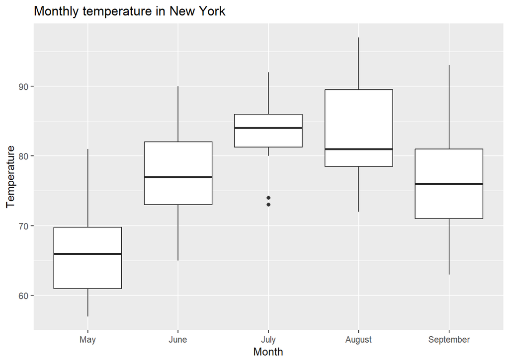

```r
ggplot(data = df, aes(Month, Temp)) +
  geom_boxplot() +
  labs(x = "Month", y = "Temperature", title = "Monthly temperature in New York")
```

LUBRIDATE

```r
shanghai = read.csv("../data/Shanghai.csv")

head(shanghai, 3)
```

```
##   Year Month  Temp
## 1 1841     1 1.809
## 2 1841     2 3.366
## 3 1841     3 7.122
```

```r
shanghai$Date = paste0(shanghai$Year, "-", shanghai$Month)

shanghai$Date = ym(shanghai$Date)
shanghai
```

```
##      Year Month   Temp       Date
## 1    1841     1  1.809 1841-01-01
## 2    1841     2  3.366 1841-02-01
## 3    1841     3  7.122 1841-03-01
## 4    1841     4 13.306 1841-04-01
## 5    1841     5 19.007 1841-05-01
## 6    1841     6 22.943 1841-06-01
## 7    1841     7 27.783 1841-07-01
## 8    1841     8 27.092 1841-08-01
## 9    1841     9 22.326 1841-09-01
## 10   1841    10 16.971 1841-10-01
## 11   1841    11 11.281 1841-11-01
## 12   1841    12  5.429 1841-12-01
## 13   1842     1  3.028 1842-01-01
## 14   1842     2  4.396 1842-02-01
```

[output cut: 2050 more lines]

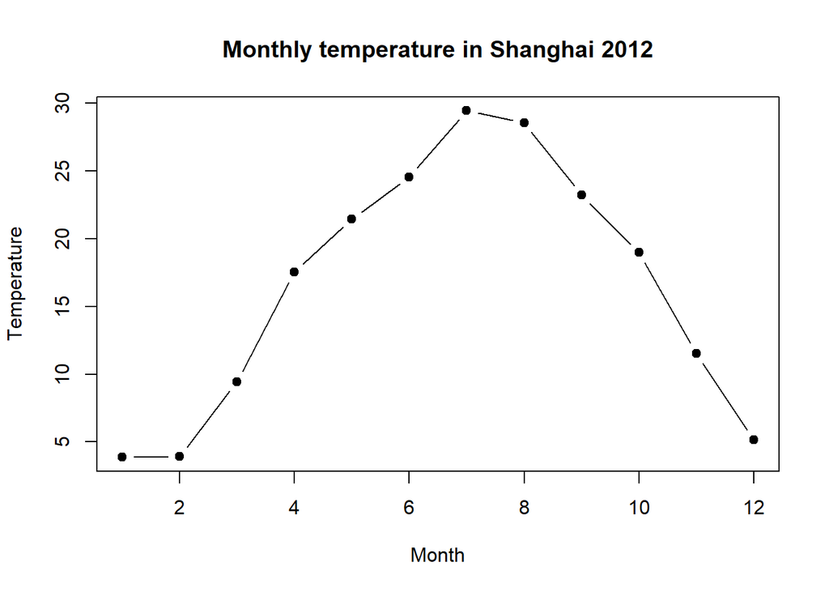

```r
shanghai_2012 = shanghai[shanghai$Year == 2012,]

plot(shanghai_2012$Month, shanghai_2012$Temp, xlab = "Month",
     ylab = "Temperature", type = "b", cex = 01, pch = 19,
     main = "Monthly temperature in Shanghai 2012")
```

FUNCTIONS

```r
# Q1.1 pass_check
pass_check = function(grade) {

  # Check if the input is numeric
  # If not, stop the current execution and print an error
  if(!is.numeric(grade)) {
    stop("The input is not numeric.")
  }

  if (grade >= 5){
    print("pass")
  } else {
    print("fail")
  }

}

factor_convert = function(df) {

  for(i in 1:ncol(df)) {

    var = df[, i]

    if(is.character(var)) {
      df[, i] = as.factor(var)
    }
  }

  return(df)

}

select(df, where(is.factor))
```

```
##         Month Season
## 1         May Summer
## 2         May Summer
## 3         May Summer
## 4         May Summer
## 7         May Summer
## 8         May Summer
## 9         May Summer
## 12        May Summer
## 13        May Summer
## 14        May Summer
## 15        May Summer
## 16        May Summer
## 17        May Summer
## 18        May Summer
```

[output cut: 97 more lines]

```r
df[,sapply(df, is.factor)]
```

```
##         Month Season
## 1         May Summer
## 2         May Summer
## 3         May Summer
## 4         May Summer
## 7         May Summer
## 8         May Summer
## 9         May Summer
## 12        May Summer
## 13        May Summer
## 14        May Summer
## 15        May Summer
## 16        May Summer
## 17        May Summer
## 18        May Summer
```

[output cut: 97 more lines]

RDS

```r
hawk = readRDS("../data/hawker_ctr_raw.rds")
hawk = hawk[[1]][-1]

all_names = sapply(hawk, function(x) x$NAME)

compute_dist = function(name1, name2) {

  id_1 = which(all_names == name1)
  id_2 = which(all_names == name2)

  coord_1 = as.numeric(str_split(hawk[[id_1]]$XY, ",")[[1]])
  coord_2 = as.numeric(str_split(hawk[[id_2]]$XY, ",")[[1]])

  dist = sqrt(sum((coord_1 - coord_2)^2))
  dist
}

dist_example = compute_dist("Tanglin Halt Market", "Taman Jurong Market & Food Centre")

hawk_combn = combn(all_names, 2)
compute_dist_v = Vectorize(compute_dist)
all_dist = compute_dist_v(hawk_combn[1, ], hawk_combn[2, ])
dist_df = data.frame(hawker1 = hawk_combn[1, ],
                     hawker2 = hawk_combn[2, ],
                     dist = all_dist, stringsAsFactors = FALSE)

dist_df
```

```
##                                     hawker1
## 1        Blks 1A/ 2A/ 3A Commonwealth Drive
## 2        Blks 1A/ 2A/ 3A Commonwealth Drive
## 3        Blks 1A/ 2A/ 3A Commonwealth Drive
## 4        Blks 1A/ 2A/ 3A Commonwealth Drive
## 5        Blks 1A/ 2A/ 3A Commonwealth Drive
## 6        Blks 1A/ 2A/ 3A Commonwealth Drive
## 7        Blks 1A/ 2A/ 3A Commonwealth Drive
## 8        Blks 1A/ 2A/ 3A Commonwealth Drive
## 9        Blks 1A/ 2A/ 3A Commonwealth Drive
## 10       Blks 1A/ 2A/ 3A Commonwealth Drive
## 11       Blks 1A/ 2A/ 3A Commonwealth Drive
## 12       Blks 1A/ 2A/ 3A Commonwealth Drive
## 13       Blks 1A/ 2A/ 3A Commonwealth Drive
## 14       Blks 1A/ 2A/ 3A Commonwealth Drive
```

[output cut: 13327 more lines]

TIDY DATA

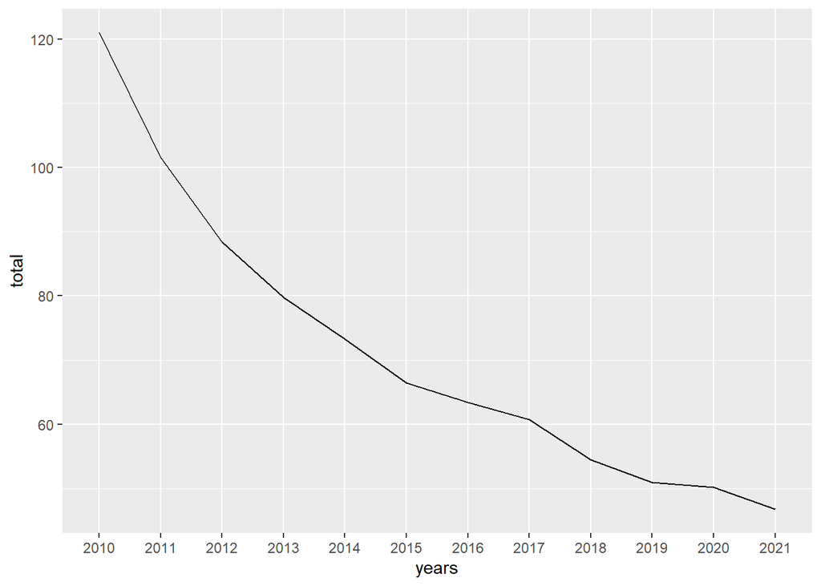

```r
unicef_hiv_tidy = read_excel("../data/unicef_hiv_data.xlsx",
                             range = "A1:O219", na = c("-", "<0.01")) %>%
  filter(!(row_number() %in% c(1,2))) %>%
  gather(`2021`:`2010`, key = "years", value = "values") %>%
  mutate(values = as.numeric(values)) %>%
  spread(key = indicator, value = values) %>%
  rename(incidence = 4,
         deaths = 5,
         country = 1)



global_evolution = unicef_hiv_tidy %>%
  group_by(years) %>%
  summarize(total = sum(incidence, na.rm = TRUE)) %>%
  ungroup()

ggplot(data = global_evolution, aes(years, total)) +
  geom_line(aes(group = 1))
```

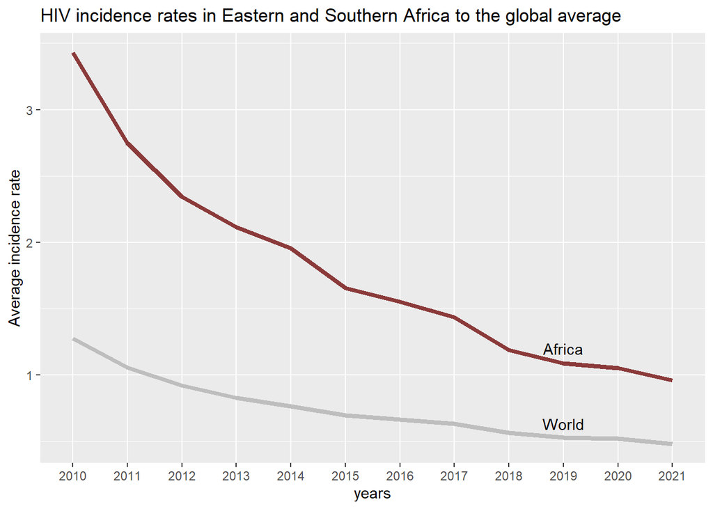

```r
iso_unicef = read.csv("../data/iso_unicef_region.csv")

overall = unicef_hiv_tidy %>% left_join(iso_unicef, by = c("country" = "Country.Region")) %>%
  filter(!(is.na(UNICEF.Region)))

global_average = overall %>%
  group_by(years) %>%
  summarize(avg = mean(incidence, na.rm = TRUE)) %>%
  ungroup()


africa = overall %>% filter(UNICEF.Region == "Eastern and Southern Africa") %>%
  group_by(years) %>%
  summarize(avg = mean(incidence)) %>%
  ungroup()

ggplot(data = africa) +
  geom_line(aes(years, avg, group = 1), color = "indianred4", linewidth = 1.5) +
  geom_line(data = global_average, aes(years, avg, group = 1), color = "grey", linewidth = 1.5) +
  annotate(geom = "text", x = 10, y = 1.2, label = "Africa") +
  annotate(geom = "text", x = 10, y = 0.63, label = "World") +
  labs(y = "Average incidence rate",
  title = "HIV incidence rates in Eastern and Southern Africa to the global average")
```

JOINS

```r
themes = read.csv("../data/archive/themes.csv")
sets = read.csv("../data/archive/sets.csv")
inventory_sets = read.csv("../data/archive/inventory_sets.csv")
colors = read.csv("../data/archive/colors.csv")
inventories = read.csv("../data/archive/inventories.csv")
inventory_parts = read.csv("../data/archive/inventory_parts.csv")
parts = read.csv("../data/archive/parts.csv")
part_categories = read.csv("../data/archive/part_categories.csv")

part_cat = part_categories %>%
  filter(str_detect(name, "Bricks"))

themes %>% anti_join(sets, by = c("id" = "theme_id")) %>% count()
```

```
##    n
## 1 39
```

```r
brick_parts = inventory_parts %>%
  left_join(colors, by = c("color_id" = "id")) %>%
  left_join(parts, by = c("part_num" = "part_num")) %>%
  left_join(part_cat, by = c("part_cat_id" = "id")) %>%
  rename(part_name = 2,
         part_cat_name = 3,
         color_name = 4) %>%
  na.omit()



inv_parts_col = inventory_parts %>% left_join(colors, by = c("color_id" = "id"))
parts_cat = parts %>% left_join(part_categories, by = c("part_cat_id" = "id"),
                                suffix = c("_parts", "_cats")) %>%
  filter(str_detect(name_cats, "Bricks"))

table = inv_parts_col %>% left_join(parts_cat, by = c("part_num" = "part_num")) %>%
  filter(!(is.na(name_cats))) %>%
  select(part_num, name_parts, name_cats, name, rgb)


pop_themes = themes %>%
  left_join(sets, by = c("id" = "theme_id"), suffix = c("_themes", "_sets")) %>%
  filter(str_detect(name_themes, "Star Wars")) %>%
  group_by(year) %>%
  summarize(numSets = n_distinct(set_num),
            avg = ceiling(mean(num_parts)))

nrow(sets)
```

```
## [1] 11673
```

```r
nrow(inventories)
```

```
## [1] 11681
```

```r
sets %>% left_join(inventories) %>%
  group_by(set_num) %>%
  count() %>%
  filter(n > 1)
```

```
## # A tibble: 8 × 2
## # Groups:   set_num [8]
##   set_num     n
##   <chr>   <int>
## 1 11905-1     2
## 2 214.6-1     2
## 3 31015-1     2
## 4 421-2       5
## 5 6515-1      2
## 6 75053-1     2
## 7 8030-1      2
## 8 8880-1      2
```

MIDTERMS

```r
tset = tibble::tribble(
  ~abb, ~full, ~number,
  "Jan", "January", 1,
  "Feb", "February", 2,
  "Mar", "March", 3,
  "Apr", "April", 4,
  "May", "May", 5
)

tset %>% mutate(a = match(abb, month.abb))
```

```
## # A tibble: 5 × 4
##   abb   full     number     a
##   <chr> <chr>     <dbl> <int>
## 1 Jan   January       1     1
## 2 Feb   February      2     2
## 3 Mar   March         3     3
## 4 Apr   April         4     4
## 5 May   May           5     5
```

```r
tset %>% mutate(a = match(full, month.name))
```

```
## # A tibble: 5 × 4
##   abb   full     number     a
##   <chr> <chr>     <dbl> <int>
## 1 Jan   January       1     1
## 2 Feb   February      2     2
## 3 Mar   March         3     3
## 4 Apr   April         4     4
## 5 May   May           5     5
```